# RM-ANOVA for coevolution with a seed bank

## Population density data

I have previously consolidated all the data on population density collected for this experiment. This includes:

| Population | What it is | Method of measurement |
| --- | --- | --- |
| spore / mL | host spore density | flow-cytometry: low SYBR population |
| veg / mL | host vegetative cell density | flow-cytometry: high SYBR population |
| cell /mL | total host cell density (spore+veg) | flow-cytometry |
| phage/ mL | total SPO1 phage density (free phage) | qPCR (SYBR) with phage specific primers and lysate serial dilution as standard |

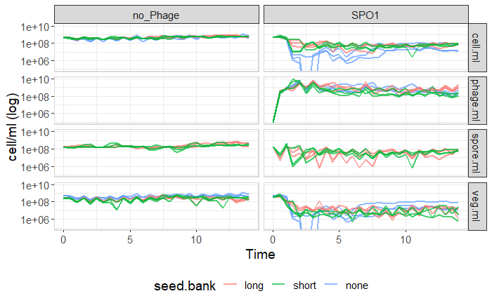

In the first few days of the experiment cell numbers dropped below detection limit in 2 of 3 SNO lines. Missing data cannot be analyzed in RM-ANOVA. I will assign these points the detection limit values.

Points with missing data:

```r
d%>%
  filter(cell.ml<10)
```

| culture | line | Time | seed.bank | phage.ml | spore.ml | veg.ml | cell.ml | host | phage | flask |
| --- | --- | --- | --- | --- | --- | --- | --- | --- | --- | --- |
| SNO | L2 | 2.5 | none | 531673865 | 1 | 1 | 2 | dSpoIIE | SPO1 | SNO-L2 |
| SNO | L3 | 2.5 | none | 697684098 | 1 | 1 | 2 | dSpoIIE | SPO1 | SNO-L3 |
| SNO | L2 | 3.0 | none | 3627628662 | 1 | 1 | 2 | dSpoIIE | SPO1 | SNO-L2 |

These are all veg cells:

```r
d%>%
  filter(veg.ml<10)
```

[output not shown]

**Flow-cytometry detection limit**

The flow cytometer stop conditions were either $50\mu L$ or 50,000 events, whatever came first.  
In addition, to account for false asignments by noise I required that a gated population have at least 100 events to be taken into account. So the minimal detected population would have 100 cells in $50\mu L$ of analyzed liquid. At this poimt of the experiment we were analyzing x100 diluted samples.

```r
detection.limit <- 100 * (1000/50) * 100
```

I will use $1X10^5$, half the detection limit dor missing value points

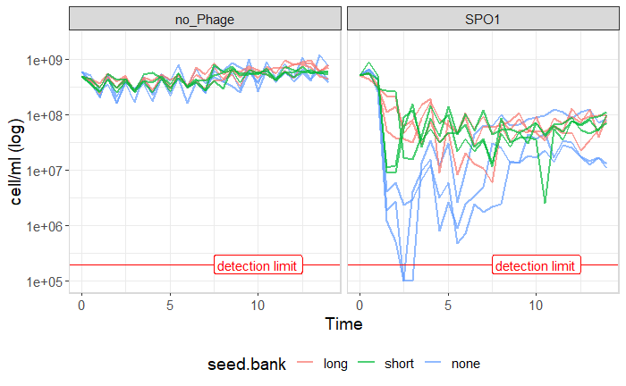

```r
d <- d%>%
  mutate(cell.ml=if_else(cell.ml>10, cell.ml,detection.limit/2))%>%
  mutate(veg.ml=if_else(veg.ml>10, veg.ml,detection.limit/2))


# plot total cells of raw data
d%>%
    ggplot(aes(x=Time, y=cell.ml))+
      geom_line(aes(group=flask,color=seed.bank), size=1, alpha=0.7)+
  geom_hline(yintercept = detection.limit, color="red")+
  geom_label(label="detection limit", x=10, y=log10(detection.limit), color="red")+
      facet_wrap(~phage)+
      theme_bw()+
      panel_border()+
      scale_y_log10()+
      theme(legend.position = "bottom",
            text=element_text(size=14))+
      ylab("cell/ml (log)")+
      coord_cartesian(ylim = c(1e5, 2e9))
```

# RM-ANOVA with raw data (untransformed)

### Adjusting variable types for lme

In the lme models I will be using the fixd effects need to be secified as factore, in this experiment these ar: *Phage, seed.bank and time*. However for the autocorrelation specification time needs to be specified as an integer. To fulfill both requirements I will use for the time unit the experimental day rather than transfer, since we measured onc a day but twice per transfer. This will be simplty *time x 2*. I will then make fom that a separate varible which will be the factor of the time.

```r
d.4stat <-
  d%>%
  # remove setup data
  filter(Time>=0)%>%
  #make time an integer for correlation structure
  # by converting to days as time unit
  mutate(Time=as.integer(2*Time))%>%
  # for the lme model all fixed effects need to be factors
  mutate(time.fct=as.factor(Time))%>%
  mutate(seed.bank=as.factor(seed.bank))%>%
  mutate(phage=as.factor(phage))
```

#### test data for homogeneity of variances

This is an assumption of ANOVA tests.

Based on : https://www.datanovia.com/en/lessons/homogeneity-of-variance-test-in-r/ Using “Levene’s test” that according to website is the most commonly used test for this purpose. This tets has a null hypothesis of equal variance. So getting P>0.05 suggests homogenic variance.

```r
# Levene's test with multiple independent variables
car::leveneTest(cell.ml ~ phage*seed.bank*line, data = d.4stat)
```

```
Levene's Test for Homogeneity of Variance (center = median)
       Df F value    Pr(>F)
group  17  2.6729 0.0003258 ***
      504
---
Signif. codes:  0 ‘***’ 0.001 ‘**’ 0.01 ‘*’ 0.05 ‘.’ 0.1 ‘ ’ 1
```

The data does not fulfill the assumption of equal variance across test groups.

```r
pd1 <-
  d.4stat%>%
    ggplot(aes(x = cell.ml, color = line))+
  geom_density()+
  facet_grid(seed.bank~phage)+
  theme_cowplot()+panel_border()

pd2 <-
  ggqqplot(d.4stat$cell.ml)
```

## RM-Anova with corAR1 covariance structure

I continue the analysis with the untatnsformed data.

```r
rm.ar1 <-
  d.4stat%>%
  # looking only at total cells (cell.ml)
    lme(cell.ml ~ phage * seed.bank * time.fct ,
    # lme(log10(cell.ml) ~ phage * seed.bank * time.fct ,
        random = ~1|flask,
        correlation = corAR1(form = ~ Time | flask),
        data = .)

anova.lme(rm.ar1)
```

|  | numDF | denDF | F-value | p-value |
| --- | --- | --- | --- | --- |
| (Intercept) | 1 | 336 | 2368.2534 | <.0001 |
| phage | 1 | 12 | 986.1352 | <.0001 |
| seed.bank | 2 | 12 | 4.0142 | 0.0463 |
| time.fct | 28 | 336 | 17.8685 | <.0001 |
| phage:seed.bank | 2 | 12 | 1.2543 | 0.3201 |
| phage:time.fct | 28 | 336 | 26.4863 | <.0001 |
| seed.bank:time.fct | 56 | 336 | 1.9517 | 0.0002 |
| phage:seed.bank:time.fct | 56 | 336 | 1.4433 | 0.0273 |

#### Distribution of model residuals

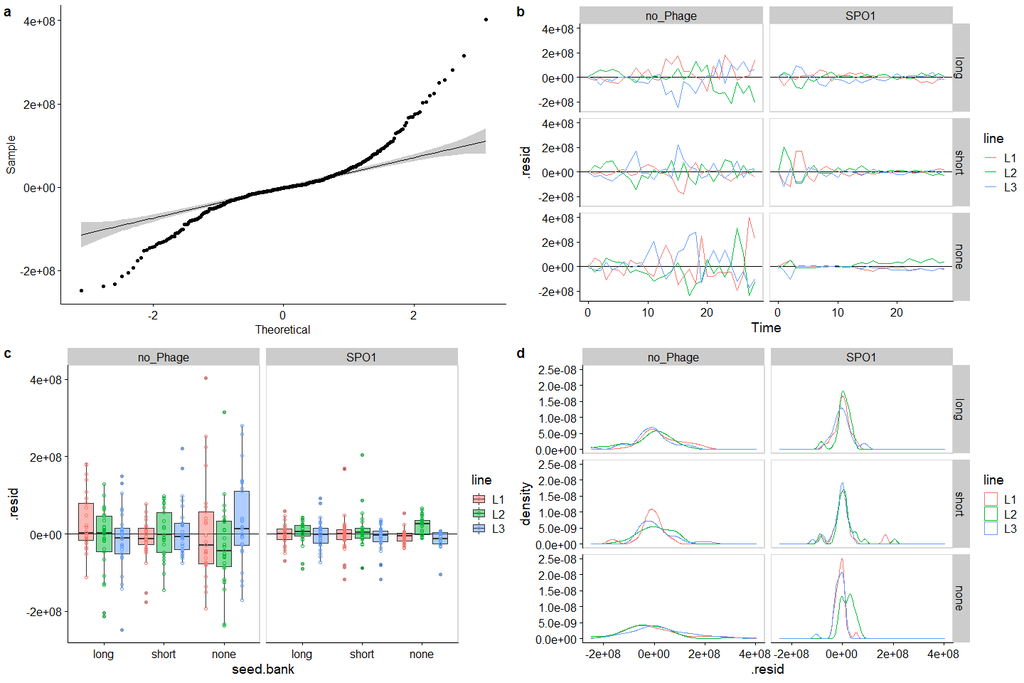

```r
p1 <- ggqqplot(residuals(rm.ar1))

p2 <-
broom.mixed::augment(rm.ar1)%>%
  ggplot(aes(Time,.resid)) +
  geom_hline(yintercept = 0)+
  geom_line(aes(color=line))+
  facet_grid(seed.bank~phage)+
  theme_cowplot()+panel_border()
p3 <-
broom.mixed::augment(rm.ar1)%>%
  ggplot(aes(seed.bank,.resid)) +
  geom_hline(yintercept = 0)+
  geom_boxplot(aes(fill=line),alpha=.5, position = position_dodge(width = .9))+
  geom_point(aes(color=line), position = position_dodge(width = .9), shape=21)+
  facet_wrap(~phage)+
  theme_cowplot()+panel_border()

p4 <-
broom.mixed::augment(rm.ar1)%>%
  ggplot(aes(x = .resid, color = line))+
  geom_density()+
  facet_grid(seed.bank~phage)+
  theme_cowplot()+panel_border()

plot_grid(p1,p2,p3,p4, nrow = 2, labels = 'auto')
```

The QQ-plot (a) shows large departure of residulas from normality. Shapiro test for normality of residuals applied to each of the groups (individual culture).

```r
d.resid <-
  broom.mixed::augment(rm.ar1)%>%
  select(.resid,phage,seed.bank,line)%>%
  group_by(phage,seed.bank,line)%>%
summarise(p.shapiro = shapiro.test(unlist(.resid))$p.value,.groups = 'drop')%>%
  mutate(normal=if_else(p.shapiro>=0.05,TRUE,FALSE))%>%
  arrange(desc(p.shapiro))%>%
  print()
```

| phage | seed.bank | line | p.shapiro | normal |
| --- | --- | --- | --- | --- |
| SPO1 | long | L1 | 8.488029e-01 | TRUE |
| no_Phage | short | L2 | 3.781891e-01 | TRUE |
| SPO1 | long | L3 | 3.033941e-01 | TRUE |
| no_Phage | none | L3 | 2.590756e-01 | TRUE |
| no_Phage | long | L3 | 2.293970e-01 | TRUE |
| no_Phage | long | L2 | 7.264263e-02 | TRUE |
| SPO1 | none | L2 | 5.497206e-02 | TRUE |
| no_Phage | none | L2 | 5.127058e-02 | TRUE |
| no_Phage | long | L1 | 4.282706e-02 | FALSE |
| SPO1 | none | L1 | 2.012541e-02 | FALSE |

[output cut: 8 more lines]

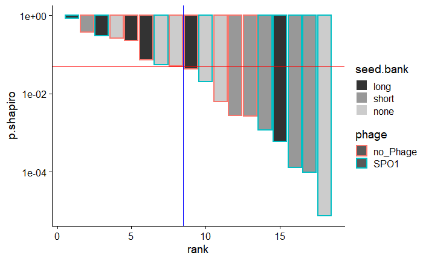

```r
n.norm=sum(d.resid$normal)

d.resid%>%
  arrange(desc(p.shapiro))%>%
  ungroup()%>%
  mutate(rank=row_number())%>%
  ggplot(aes(rank, p.shapiro))+
  geom_col(aes(fill=seed.bank, color=phage),size=1)+
  geom_hline(yintercept = 0.05, color="red")+
  geom_vline(xintercept = n.norm+.5, color="blue")+
  scale_fill_grey()+
  scale_y_log10()+
  theme_cowplot()
```

Groups with p.shapiro>0.05 are considered normally distributed (Above the res lie, left of the blue line). Here we have 8 such groups (of 18).

# Box-Cox transformation

```r
# Multivariate transformation to normality within levels of 'htype'
summary(bc <-  powerTransform(cell.ml ~ phage*seed.bank*line, d.4stat))
```

```
bcPower Transformation to Normality
   Est Power Rounded Pwr Wald Lwr Bnd Wald Upr Bnd
Y1    0.3385        0.33       0.2893       0.3877

Likelihood ratio test that transformation parameter is equal to 0
 (log transformation)
```

|  | LRT | df | pval |
| --- | --- | --- | --- |
| LR test, lambda = (0) | 254.1126 | 1 | < 2.22e-16 |

```
Likelihood ratio test that no transformation is needed
```

|  | LRT | df | pval |
| --- | --- | --- | --- |
| LR test, lambda = (1) | 427.8203 | 1 | < 2.22e-16 |

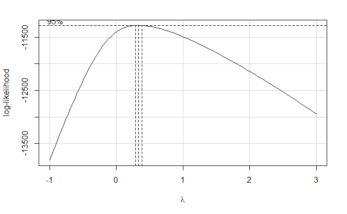

```r
  with(d.4stat, boxCox(cell.ml ~ phage*seed.bank*line,
         lambda = seq(-1, 3, len = 40), family="bcPower"))
```

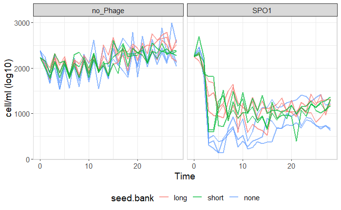

```r
# with(d.4stat, plot(bc, col=as.numeric(htype)))
d.4stat <-
  d%>%
  # remove setup data
  filter(Time>=0)%>%
  #make time an integer for correlation structure
  # by converting to days as time unit
  mutate(Time=as.integer(2*Time))%>%
  # for the lme model all fixed effects need to be factors
  mutate(time.fct=as.factor(Time))%>%
  mutate(seed.bank=as.factor(seed.bank))%>%
  mutate(phage=as.factor(phage))%>%
  mutate(cell.ml=bcPower(cell.ml, bc$roundlam))

d.4stat %>%
  ggplot(aes(x=Time, y=cell.ml))+
      geom_line(aes(group=flask,color=seed.bank), size=1, alpha=0.7)+
        facet_wrap(~phage)+
      theme_bw()+
      panel_border()+
      theme(legend.position = "bottom",
            text=element_text(size=14))+
      ylab("cell/ml (log10)")
```

#### test data for homogeneity of variances

```r
# Levene's test with multiple independent variables
car::leveneTest(cell.ml ~ phage*seed.bank*line, data = d.4stat)
```

```
Levene's Test for Homogeneity of Variance (center = median)
       Df F value  Pr(>F)
group  17  1.6014 0.05948 .
      504
---
Signif. codes:  0 ‘***’ 0.001 ‘**’ 0.01 ‘*’ 0.05 ‘.’ 0.1 ‘ ’ 1
```

Passes this test, barely.

```r
pd1.bc <-
  d.4stat%>%
    ggplot(aes(x = cell.ml, color = line))+
  geom_density()+
  facet_grid(seed.bank~phage)+
  theme_cowplot()+panel_border()

pd2.bc <-
  ggqqplot(d.4stat$cell.ml)
```

#### RM-Anova with corAR1 covariance structure

```r
rm.ar1 <-
  d.4stat%>%
  # looking only at total cells (cell.ml)
    lme(cell.ml ~ phage * seed.bank * time.fct ,
    # lme(log10(cell.ml) ~ phage * seed.bank * time.fct ,
        random = ~1|flask,
        correlation = corAR1(form = ~ Time | flask),
        data = .)

anova.lme(rm.ar1)
```

|  | numDF | denDF | F-value | p-value |
| --- | --- | --- | --- | --- |
| (Intercept) | 1 | 336 | 6026.806 | <.0001 |
| phage | 1 | 12 | 622.644 | <.0001 |
| seed.bank | 2 | 12 | 9.773 | 0.0030 |
| time.fct | 28 | 336 | 15.775 | <.0001 |
| phage:seed.bank | 2 | 12 | 4.122 | 0.0434 |
| phage:time.fct | 28 | 336 | 29.469 | <.0001 |
| seed.bank:time.fct | 56 | 336 | 2.478 | <.0001 |
| phage:seed.bank:time.fct | 56 | 336 | 1.440 | 0.0280 |

#### Distribution of model residuals

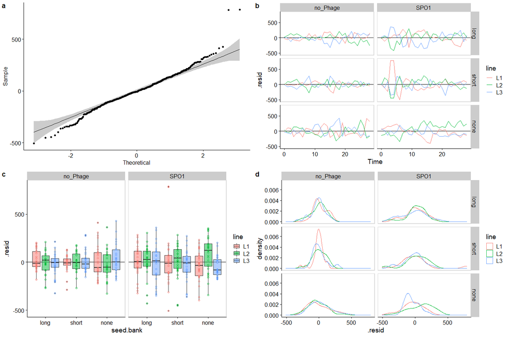

```r
p1 <- ggqqplot(residuals(rm.ar1))

p2 <-
broom.mixed::augment(rm.ar1)%>%
  ggplot(aes(Time,.resid)) +
  geom_hline(yintercept = 0)+
  geom_line(aes(color=line))+
  facet_grid(seed.bank~phage)+
  theme_cowplot()+panel_border()

p3 <-
broom.mixed::augment(rm.ar1)%>%
  ggplot(aes(seed.bank,.resid)) +
  geom_hline(yintercept = 0)+
  geom_boxplot(aes(fill=line),alpha=.5, position = position_dodge(width = .9))+
  geom_point(aes(color=line), position = position_dodge(width = .9), shape=21)+
  facet_wrap(~phage)+
  theme_cowplot()+panel_border()

p4 <-
broom.mixed::augment(rm.ar1)%>%
  ggplot(aes(x = .resid, color = line))+
  geom_density()+
  facet_grid(seed.bank~phage)+
  theme_cowplot()+panel_border()

plot_grid(p1,p2,p3,p4, nrow = 2, labels = 'auto')
```

Shapiro test for normality of residuals applied to each of the groups (individual culture).

```r
d.resid <-
  broom.mixed::augment(rm.ar1)%>%
  select(.resid,phage,seed.bank,line)%>%
  group_by(phage,seed.bank,line)%>%
summarise(p.shapiro = shapiro.test(unlist(.resid))$p.value,.groups = 'drop')%>%
  mutate(normal=if_else(p.shapiro>=0.05,TRUE,FALSE))%>%
  arrange(desc(p.shapiro))%>%
  print()
```

| phage | seed.bank | line | p.shapiro | normal |
| --- | --- | --- | --- | --- |
| SPO1 | none | L1 | 0.735609791 | TRUE |
| no_Phage | none | L2 | 0.729181432 | TRUE |
| no_Phage | short | L2 | 0.659080316 | TRUE |
| SPO1 | long | L1 | 0.481822250 | TRUE |
| no_Phage | long | L3 | 0.453707912 | TRUE |
| SPO1 | short | L3 | 0.321543935 | TRUE |
| SPO1 | none | L2 | 0.300306012 | TRUE |
| SPO1 | long | L3 | 0.297339747 | TRUE |
| no_Phage | long | L2 | 0.289038702 | TRUE |
| no_Phage | none | L3 | 0.181528478 | TRUE |

[output cut: 8 more lines]

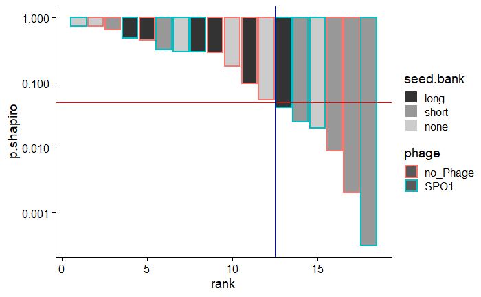

```r
n.norm=sum(d.resid$normal)

d.resid%>%
  arrange(desc(p.shapiro))%>%
  ungroup()%>%
  mutate(rank=row_number())%>%
  ggplot(aes(rank, p.shapiro))+
  geom_col(aes(fill=seed.bank, color=phage),size=1)+
  geom_hline(yintercept = 0.05, color="red")+
  geom_vline(xintercept = n.norm+.5, color="blue")+
  scale_fill_grey()+
  scale_y_log10()+
  theme_cowplot()
```

# log transformed data

This is the standard approach to reduce data variability when data encomapsses several orders of magnitude.

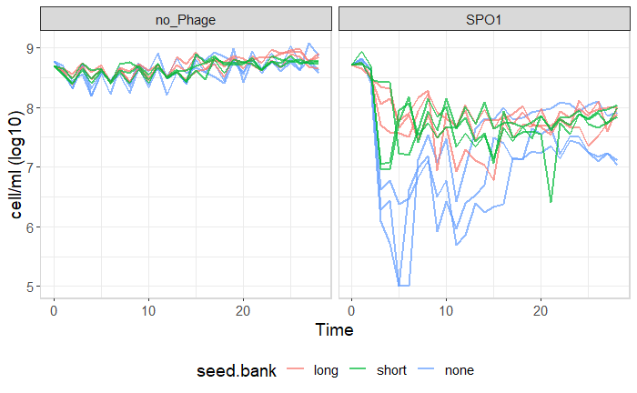

```r
d.4stat <-
  d%>%
  # remove setup data
  filter(Time>=0)%>%
  #make time an integer for correlation structure
  # by converting to days as time unit
  mutate(Time=as.integer(2*Time))%>%
  # for the lme model all fixed effects need to be factors
  mutate(time.fct=as.factor(Time))%>%
  mutate(seed.bank=as.factor(seed.bank))%>%
  mutate(phage=as.factor(phage))%>%
  mutate(cell.ml=log10(cell.ml))

d.4stat %>%
  ggplot(aes(x=Time, y=cell.ml))+
      geom_line(aes(group=flask,color=seed.bank), size=1, alpha=0.7)+
        facet_wrap(~phage)+
      theme_bw()+
      panel_border()+
      theme(legend.position = "bottom",
            text=element_text(size=14))+
      ylab("cell/ml (log10)")
```

#### test data for homogeneity of variances

```r
# Levene's test with multiple independent variables
car::leveneTest(cell.ml ~ phage*seed.bank*line, data = d.4stat)
```

```
Levene's Test for Homogeneity of Variance (center = median)
       Df F value    Pr(>F)
group  17  8.6442 < 2.2e-16 ***
      504
---
Signif. codes:  0 ‘***’ 0.001 ‘**’ 0.01 ‘*’ 0.05 ‘.’ 0.1 ‘ ’ 1
```

This test indicates an increased departure from the equal variances.

```r
pd1.log <-
  d.4stat%>%
    ggplot(aes(x = cell.ml, color = line))+
  geom_density()+
  facet_grid(seed.bank~phage)+
  theme_cowplot()+panel_border()

pd2.log <-
  ggqqplot(d.4stat$cell.ml)
```

#### RM-Anova with corAR1 covariance structure

```r
rm.ar1 <-
  d.4stat%>%
  # looking only at total cells (cell.ml)
    lme(cell.ml ~ phage * seed.bank * time.fct ,
    # lme(log10(cell.ml) ~ phage * seed.bank * time.fct ,
        random = ~1|flask,
        correlation = corAR1(form = ~ Time | flask),
        data = .)

anova.lme(rm.ar1)
```

|  | numDF | denDF | F-value | p-value |
| --- | --- | --- | --- | --- |
| (Intercept) | 1 | 336 | 78564.56 | <.0001 |
| phage | 1 | 12 | 300.53 | <.0001 |
| seed.bank | 2 | 12 | 13.79 | 0.0008 |
| time.fct | 28 | 336 | 9.18 | <.0001 |
| phage:seed.bank | 2 | 12 | 10.00 | 0.0028 |
| phage:time.fct | 28 | 336 | 16.78 | <.0001 |
| seed.bank:time.fct | 56 | 336 | 2.82 | <.0001 |
| phage:seed.bank:time.fct | 56 | 336 | 2.52 | <.0001 |

#### Distribution of model residuals

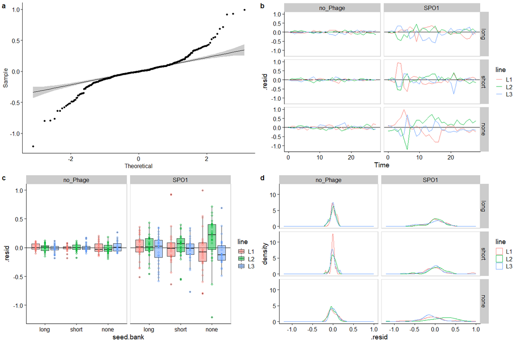

```r
p1 <- ggqqplot(residuals(rm.ar1))

p2 <-
broom.mixed::augment(rm.ar1)%>%
  ggplot(aes(Time,.resid)) +
  geom_hline(yintercept = 0)+
  geom_line(aes(color=line))+
  facet_grid(seed.bank~phage)+
  theme_cowplot()+panel_border()

p3 <-
broom.mixed::augment(rm.ar1)%>%
  ggplot(aes(seed.bank,.resid)) +
  geom_hline(yintercept = 0)+
  geom_boxplot(aes(fill=line),alpha=.5, position = position_dodge(width = .9))+
  geom_point(aes(color=line), position = position_dodge(width = .9), shape=21)+
  facet_wrap(~phage)+
  theme_cowplot()+panel_border()

p4 <-
broom.mixed::augment(rm.ar1)%>%
  ggplot(aes(x = .resid, color = line))+
  geom_density()+
  facet_grid(seed.bank~phage)+
  theme_cowplot()+panel_border()

plot_grid(p1,p2,p3,p4, nrow = 2, labels = 'auto')
```

Shapiro test for normality of residuals applied to each of the groups (individual culture).

```r
d.resid <-
  broom.mixed::augment(rm.ar1)%>%
  select(.resid,phage,seed.bank,line)%>%
  group_by(phage,seed.bank,line)%>%
summarise(p.shapiro = shapiro.test(unlist(.resid))$p.value,.groups = 'drop')%>%
  mutate(normal=if_else(p.shapiro>=0.05,TRUE,FALSE))%>%
  arrange(desc(p.shapiro))%>%
  print()
```

| phage | seed.bank | line | p.shapiro | normal |
| --- | --- | --- | --- | --- |
| no_Phage | none | L2 | 0.9039216085 | TRUE |
| no_Phage | short | L2 | 0.6779896474 | TRUE |
| no_Phage | long | L3 | 0.4357690781 | TRUE |
| no_Phage | long | L2 | 0.4314897065 | TRUE |
| SPO1 | long | L2 | 0.3077592714 | TRUE |
| SPO1 | long | L1 | 0.2531466237 | TRUE |
| SPO1 | none | L1 | 0.1759653972 | TRUE |
| SPO1 | long | L3 | 0.1193422640 | TRUE |
| no_Phage | none | L1 | 0.1030319983 | TRUE |
| no_Phage | long | L1 | 0.0970546552 | TRUE |

[output cut: 8 more lines]

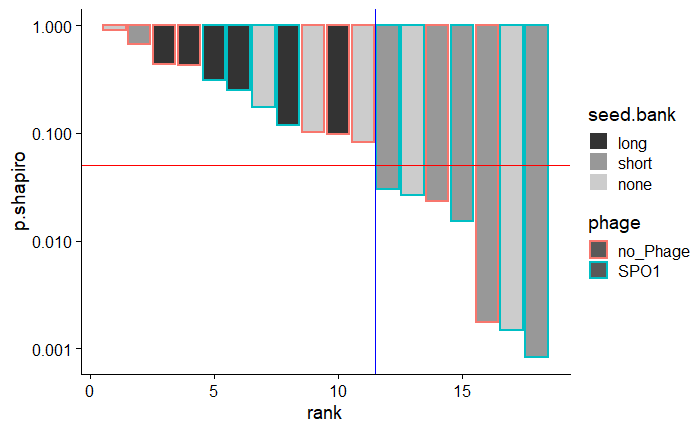

```r
n.norm=sum(d.resid$normal)

d.resid%>%
  arrange(desc(p.shapiro))%>%
  ungroup()%>%
  mutate(rank=row_number())%>%
  ggplot(aes(rank, p.shapiro))+
  geom_col(aes(fill=seed.bank, color=phage),size=1)+
  geom_hline(yintercept = 0.05, color="red")+
  geom_vline(xintercept = n.norm+.5, color="blue")+
  scale_fill_grey()+
  scale_y_log10()+
  theme_cowplot()
```

More of the groups (11/18) now have normally distributed residulas, but not all.

# square root transformed data

Another common approaach to reducing skewness of data. I will try it out.

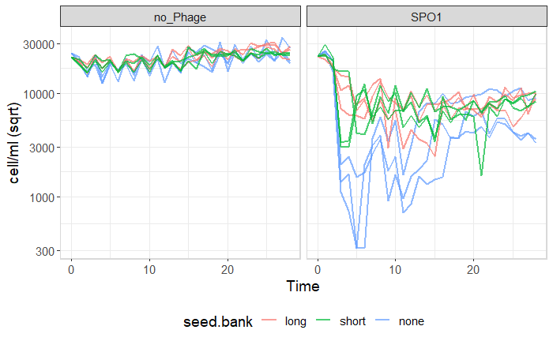

```r
d.4stat <-
  d%>%
  # remove setup data
  filter(Time>=0)%>%
  #make time an integer for correlation structure
  # by converting to days as time unit
  mutate(Time=as.integer(2*Time))%>%
  # for the lme model all fixed effects need to be factors
  mutate(time.fct=as.factor(Time))%>%
  mutate(seed.bank=as.factor(seed.bank))%>%
  mutate(phage=as.factor(phage))%>%
  mutate(cell.ml=sqrt(cell.ml))


d.4stat %>%
  ggplot(aes(x=Time, y=cell.ml))+
      geom_line(aes(group=flask,color=seed.bank), size=1, alpha=0.7)+
        facet_wrap(~phage)+
      theme_bw()+
      panel_border()+
      theme(legend.position = "bottom",
            text=element_text(size=14))+
      ylab("cell/ml (sqrt)")+scale_y_log10()
```

#### test data for homogeneity of variances

```r
# Levene's test with multiple independent variables
car::leveneTest(cell.ml ~ phage*seed.bank*line, data = d.4stat)
```

```
Levene's Test for Homogeneity of Variance (center = median)
       Df F value Pr(>F)
group  17   0.557 0.9225
      504
```

This transformation made the data have equal variance!

```r
pd1.sqrt <-
  d.4stat%>%
    ggplot(aes(x = cell.ml, color = line))+
  geom_density()+
  facet_grid(seed.bank~phage)+
  theme_cowplot()+panel_border()

pd2.sqrt <-
  ggqqplot(d.4stat$cell.ml)
```

#### RM-Anova with corAR1 covariance structure

```r
rm.ar1 <-
  d.4stat%>%
  # looking only at total cells (cell.ml)
    lme(cell.ml ~ phage * seed.bank * time.fct ,
    # lme(log10(cell.ml) ~ phage * seed.bank * time.fct ,
        random = ~1|flask,
        correlation = corAR1(form = ~ Time | flask),
        data = .)

anova.lme(rm.ar1)
```

|  | numDF | denDF | F-value | p-value |
| --- | --- | --- | --- | --- |
| (Intercept) | 1 | 336 | 4441.553 | <.0001 |
| phage | 1 | 12 | 855.083 | <.0001 |
| seed.bank | 2 | 12 | 8.467 | 0.0051 |
| time.fct | 28 | 336 | 18.469 | <.0001 |
| phage:seed.bank | 2 | 12 | 2.279 | 0.1449 |
| phage:time.fct | 28 | 336 | 32.295 | <.0001 |
| seed.bank:time.fct | 56 | 336 | 2.346 | <.0001 |
| phage:seed.bank:time.fct | 56 | 336 | 1.274 | 0.1026 |

#### Distribution of model residuals

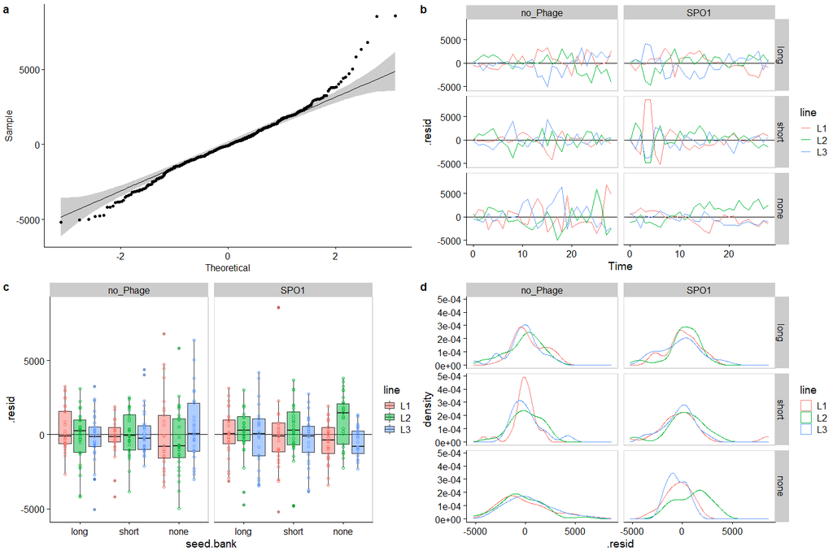

```r
p1 <- ggqqplot(residuals(rm.ar1))

p2 <-
broom.mixed::augment(rm.ar1)%>%
  ggplot(aes(Time,.resid)) +
  geom_hline(yintercept = 0)+
  geom_line(aes(color=line))+
  facet_grid(seed.bank~phage)+
  theme_cowplot()+panel_border()

p3 <-
broom.mixed::augment(rm.ar1)%>%
  ggplot(aes(seed.bank,.resid)) +
  geom_hline(yintercept = 0)+
  geom_boxplot(aes(fill=line),alpha=.5, position = position_dodge(width = .9))+
  geom_point(aes(color=line), position = position_dodge(width = .9), shape=21)+
  facet_wrap(~phage)+
  theme_cowplot()+panel_border()

p4 <-
broom.mixed::augment(rm.ar1)%>%
  ggplot(aes(x = .resid, color = line))+
  geom_density()+
  facet_grid(seed.bank~phage)+
  theme_cowplot()+panel_border()

plot_grid(p1,p2,p3,p4, nrow = 2, labels = 'auto')
```

The QQ-plot (a) shows residulas much more close to normality. Shapiro test for normality of residuals applied to each of the groups (individual culture).

```r
d.resid <-
  broom.mixed::augment(rm.ar1)%>%
  select(.resid,phage,seed.bank,line)%>%
  group_by(phage,seed.bank,line)%>%
summarise(p.shapiro = shapiro.test(unlist(.resid))$p.value,.groups = 'drop')%>%
  mutate(normal=if_else(p.shapiro>=0.05,TRUE,FALSE))%>%
  arrange(desc(p.shapiro))%>%
  print()
```

| phage | seed.bank | line | p.shapiro | normal |
| --- | --- | --- | --- | --- |
| SPO1 | none | L1 | 0.9001379378 | TRUE |
| SPO1 | long | L1 | 0.6107537227 | TRUE |
| no_Phage | none | L2 | 0.6060474388 | TRUE |
| no_Phage | short | L2 | 0.5899206954 | TRUE |
| SPO1 | short | L3 | 0.5454131225 | TRUE |
| no_Phage | long | L3 | 0.4125342819 | TRUE |
| SPO1 | none | L3 | 0.4030828342 | TRUE |
| SPO1 | none | L2 | 0.3262972456 | TRUE |
| SPO1 | long | L3 | 0.3080078183 | TRUE |
| no_Phage | none | L3 | 0.2364372421 | TRUE |

[output cut: 8 more lines]

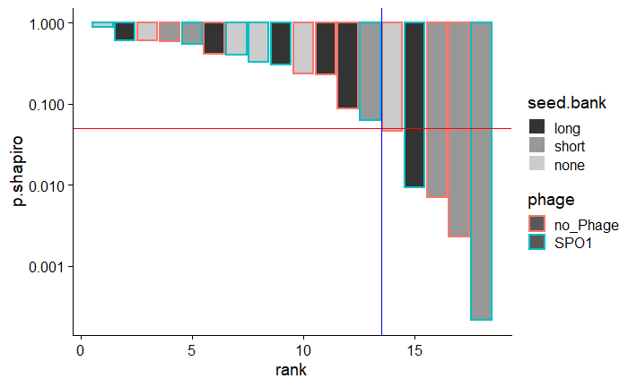

```r
n.norm=sum(d.resid$normal)

d.resid%>%
  arrange(desc(p.shapiro))%>%
  ungroup()%>%
  mutate(rank=row_number())%>%
  ggplot(aes(rank, p.shapiro))+
  geom_col(aes(fill=seed.bank, color=phage),size=1)+
  geom_hline(yintercept = 0.05, color="red")+
  geom_vline(xintercept = n.norm+.5, color="blue")+
  scale_fill_grey()+
  scale_y_log10()+
  theme_cowplot()
```

More of the groups (13/18) now have normally distributed residulas, but still not all.

# raw data

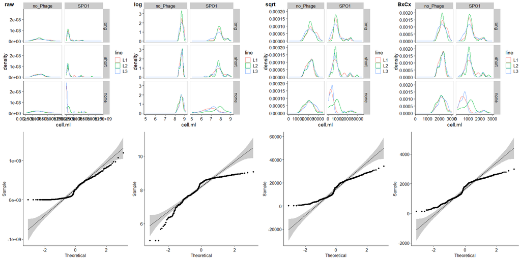

```r
plot_grid(pd1,pd1.log,pd1.sqrt,pd1.bc,pd2,pd2.log,pd2.sqrt,pd2.bc,nrow = 2, labels = c("raw","log","sqrt","BxCx","","",""))
```